# Građevinski fakultet Odsek za geodeziju i geoinformatiku Analiza podataka u R-u

Deskriptivna statistika

Petar Bursać Milutin Pejović

29 March 2023

# Ucitavanje podataka

Primer podataka sa kojima ćemo raditi danas, odnose se na cene stanova u Beogradu.

```r
# Ucitavanje podataka iz csv fajla:

stanovi <- read.csv(file = "C:/R_projects/Analiza_podataka_u_R_u/Vezbe/data/stanovi.csv", stringsAsFactors = FALSE)

head(stanovi, 10)
```

```
##              lokacija broj_soba kvadratura  sprat novogradnja
## 1           Beli dvor         2         35      P        <NA>
## 2           Beli dvor         3         52   I-II          DA
## 3           Beli dvor         2         47   I-II        <NA>
## 4           Beli dvor         2         52   I-II          DA
## 5           Beli dvor         3         80   I-II          DA
## 6  Centar, Stari grad         3         65   I-II          NE
## 7  Centar, Stari grad         2         68 III-IV          DA
## 8  Centar, Stari grad         4        160     V+        <NA>
## 9         Crveni krst         2         34 III-IV          DA
## 10        Crveni krst         1         45     V+          NE
##    centralno_grejanje lift parking uknjizen stanje cena  klasa
## 1                  DA <NA>    <NA>       DA     NA 2000 1.7-2K
## 2                  DA <NA>      NE       DA      2 2000 1.7-2K
## 3                  NE <NA>      DA       DA     NA 2000 1.7-2K
```

[output cut: 18 more lines]

U prvom koraku, upoznaćemo se podacima, nazivima kolona, dimenzijama, tipovima podataka.

```r
# Dimenzije podataka
dim(stanovi)
```

```
## [1] 1901   15
```

```r
# Tipovi podataka
str(stanovi)
```

```
## 'data.frame':    1901 obs. of  15 variables:
##  $ lokacija          : chr  "Beli dvor" "Beli dvor" "Beli dvor" "Beli dvor" ...
##  $ broj_soba         : int  2 3 2 2 3 3 2 4 2 1 ...
##  $ kvadratura        : int  35 52 47 52 80 65 68 160 34 45 ...
##  $ sprat             : chr  "P" "I-II" "I-II" "I-II" ...
##  $ novogradnja       : chr  NA "DA" NA "DA" ...
##  $ centralno_grejanje: chr  "DA" "DA" "NE" "DA" ...
##  $ lift              : chr  NA NA NA NA ...
##  $ parking           : chr  NA "NE" "DA" "DA" ...
##  $ uknjizen          : chr  "DA" "DA" "DA" "DA" ...
##  $ stanje            : int  NA 2 NA 2 2 1 2 2 2 1 ...
##  $ cena              : num  2000 2000 2000 2000 2000 2000 2000 2000 2000 2000 ...
##  $ klasa             : chr  "1.7-2K" "1.7-2K" "1.7-2K" "1.7-2K" ...
##  $ adresa            : chr  "Beli dvor, Beograd, Srbija" "Beli dvor, Beograd, Srbija" "Beli dvor, Beograd, Srbija" "Beli dvor, Beograd, Srbija" ...
##  $ latitude          : num  44.8 44.8 44.8 44.8 44.8 ...
##  $ longitude         : num  20.5 20.5 20.5 20.5 20.5 ...
```

```r
# Nazivi kolona
names(stanovi)
```

```
##  [1] "lokacija"           "broj_soba"          "kvadratura"
##  [4] "sprat"              "novogradnja"        "centralno_grejanje"
##  [7] "lift"               "parking"            "uknjizen"
## [10] "stanje"             "cena"               "klasa"
## [13] "adresa"             "latitude"           "longitude"
```

# Analiza frekvencija

Raspon cena stanova:

```r
# Koristimo funkciju range ili min i max vrednosti
min(stanovi$cena)
```

```
## [1] 900
```

```r
max(stanovi$cena)
```

```
## [1] 2000
```

```r
range(stanovi$cena)
```

```
## [1]  900 2000
```

## Tabela frekvencija

Jednostavna tabela frekvencija po atributima:

```r
# Jednostavan primer
table(stanovi$klasa)
```

```
##
##  .9-1.1K 1.1-1.3K 1.3-1.5K 1.5-1.7K   1.7-2K
##      705      494      299      217      186
```

```r
# ili po broju soba

table(stanovi$broj_soba)
```

```
##
##   1   2   3   4
## 439 635 608 219
```

```r
# ili po spratnosti

table(stanovi$sprat)
```

```
##
##   I-II III-IV      P     V+
##    750    445    251    455
```

Tabela frekvencije cene stanova sa korakom od 200 eur

```r
breaks <- seq(800, 2000, by = 200)

stanovi %<>%
  dplyr::mutate(raspon_cena = cut(cena, breaks, dig.lab = 4))

table(stanovi$raspon_cena)
```

```
##
##  (800,1000] (1000,1200] (1200,1400] (1400,1600] (1600,1800] (1800,2000]
##         379         532         420         251         192         127
```

```r
# I da kreiramo data.frame sa rezultatima

f_table_cena <- table(stanovi$raspon_cena) %>% # pozivamo table funkciju za racunanje frekvencije
  as.data.frame() %>% # kreiramo data.frame
  dplyr::rename(raspon_cena = Var1) %>% # promena naziva atributa
  dplyr::mutate("%" = round((Freq/sum(Freq)) * 100, 0)) # kreiramo novi artribut

f_table_cena
```

```
##   raspon_cena Freq  %
## 1  (800,1000]  379 20
## 2 (1000,1200]  532 28
## 3 (1200,1400]  420 22
## 4 (1400,1600]  251 13
## 5 (1600,1800]  192 10
## 6 (1800,2000]  127  7
```

Histogram frekvencije cene stanova

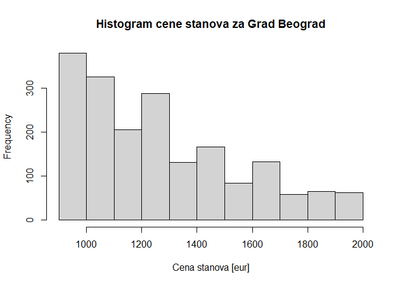

```r
hist(x = stanovi$cena,
     xlab = "Cena stanova [eur]",
     main = "Histogram cene stanova za Grad Beograd")
```

Frekvencije stanova po lokaciji

```r
f_table_lokacija <- table(stanovi$lokacija) %>% # pozivamo table funkciju za racunanje frekvencije
  as.data.frame() %>% # kreiramo data.frame
  dplyr::rename(Lokacija = Var1) %>% # promena naziva atributa
  dplyr::mutate("%" = round((Freq/sum(Freq)) * 100, 0)) # kreiramo novi artribut

f_table_lokacija %>%
  dplyr::arrange(desc(Freq))
```

```
##                           Lokacija Freq %
## 1                  Višnjicka banja   72 4
## 2                 Cukaricka padina   69 4
## 3                      Medakovic 1   56 3
## 4                      Lekino Brdo   43 2
## 5            Novi Beograd, Opština   43 2
## 6           Zemun, Save Kovacevica   41 2
## 7                    Djeram pijaca   40 2
## 8         Konjarnik, Denkova basta   40 2
## 9                      Medakovic 2   40 2
## 10                       Tašmajdan   40 2
## 11                           Cerak   39 2
## 12                    Petlovo brdo   39 2
## 13                 Cerak vinogradi   37 2
## 14                    Golf naselje   37 2
```

[output cut: 43 more lines]

Frekvencija po atributu uknjizen

```r
f_table_uknjizen <- table(stanovi$uknjizen) %>% # pozivamo table funkciju za racunanje frekvencije
  as.data.frame() %>% # kreiramo data.frame
  dplyr::rename(Uknjizen = Var1) %>% # promena naziva atributa
  dplyr::mutate("%" = round((Freq/sum(Freq)) * 100, 0)) # kreiramo novi artribut

f_table_uknjizen %>%
  dplyr::arrange(desc(Freq))
```

```
##   Uknjizen Freq  %
## 1       DA 1408 95
## 2       NE   68  5
```

## Odnos dve kategorijske promenljive (Contingency tables)

Novogradnja - Parking

```r
kon_table <- table(stanovi$novogradnja, stanovi$parking)

kon_table
```

```
##
##       DA  NE
##   DA 188  75
##   NE 172 158
```

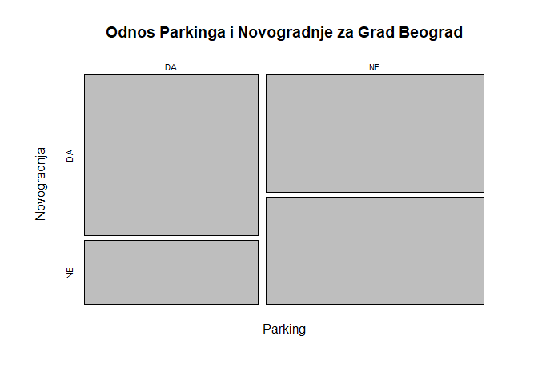

```r
mosaicplot(kon_table,
           xlab = "Parking",
           ylab = "Novogradnja",
           main = "Odnos Parkinga i Novogradnje za Grad Beograd")
```

# Mere centralne tendencije

## Raspon

Minimum (min) i maksimum (max) su najjednostavnije mere lokacije naših podataka i daju nam jasan uvid u najmanju i najveću vrednost naših podataka.

Raspon cena stanova:

```r
# Koristimo funkciju range ili min i max vrednosti
min(stanovi$cena)
```

```
## [1] 900
```

```r
max(stanovi$cena)
```

```
## [1] 2000
```

```r
range(stanovi$cena)
```

```
## [1]  900 2000
```

```r
# ili 20 najmanjih vrednosti

sort(stanovi$cena)[1:20]
```

```
##  [1] 900.0000 900.0000 900.0000 900.0000 900.0000 900.0000 900.0000 900.0000
##  [9] 900.0000 900.0000 900.0000 900.0000 900.0000 900.0000 901.5152 902.1739
## [17] 902.1739 902.3810 903.2258 903.4091
```

```r
# ili 20 najvecih vrednosti

stanovi %>%
  arrange(desc(cena)) %>%
  slice(1:20) %>%
  select(cena)
```

```
##    cena
## 1  2000
## 2  2000
## 3  2000
## 4  2000
## 5  2000
## 6  2000
## 7  2000
## 8  2000
## 9  2000
## 10 2000
## 11 2000
## 12 2000
## 13 2000
## 14 2000
## 15 2000
## 16 2000
## 17 2000
## 18 2000
## 19 2000
## 20 2000
```

Raspon vrednosti kvadrature i broja soba stanova:

```r
# Koristimo funkciju range ili min i max vrednosti

range(stanovi$kvadratura) # kvadratura
```

```
## [1]  16 375
```

```r
range(stanovi$broj_soba) # broj soba
```

```
## [1] 1 4
```

## Aritmeticka sredina

```r
# Aritmeticka sredina cene stanova

mean(stanovi$cena) # koristimo funkciju mean
```

```
## [1] 1279.991
```

Primer uticaja odskačućih rezultata na aritmeticku sredinu ako odaberemo 10 vrednosti cena (slučajnim izborom):

```r
n_10 <- sample(stanovi$cena, 10)

# Sa maksimalnim rezultatom:
mean(n_10)
```

```
## [1] 1424.476
```

```r
# Bez maksimalnog rezultata:

n_10_1 <- n_10[n_10 != max(n_10)]
mean(n_10_1)
```

```
## [1] 1360.529
```

## Težinska aritmetička sredina

Za razliku od proste aritmetičke sredine gde svi podaci učestvuju jednako, kod težinske aritmetičke sredine svakom podatku se daje određena težina:

```r
# Kao tezine mozemo ukljucti da li postoji ili ne lift ili je NA vrednost

unique(stanovi$lift)
```

```
## [1] NA   "DA" "NE"
```

```r
stanovi %<>%
  dplyr::mutate(lift_tezina = case_when(is.na(lift) ~ 0,
                                        lift == "DA" ~ 2,
                                        lift == "NE" ~ 1))

weighted.mean(stanovi$cena, stanovi$lift_tezina)
```

```
## [1] 1331.93
```

### Zadatak

> - Sracunati težinska aritmetičku sredinu, gde bi se kao težine koristili atributi: uknjižen, parking, centralno grejanje i novogradnja
> - Rezultate objediniti u jedan data.frame i uporediti sa vrednosti proste aritmetičke sredine

## Zasečena aritmetička sredina

Zasečena aritmetička sredina računa se na identičan način kao i prosta aritmetička sredina, ali ne uključuje određeni broj maksimalnih i minimalnih vrednosti.

```r
# 10% zasecena srednja vrednost

mean(stanovi$cena, trim = 0.1)
```

```
## [1] 1251.063
```

## Medijana

```r
# Za računanje medijane koristimo funkciju median

median(stanovi$cena)
```

```
## [1] 1217.391
```

```r
# Vrednost medijane po grupama cene stanova

mean_median_grupe <- stanovi %>% dplyr::group_by(raspon_cena) %>%
  dplyr::summarize(cena_mean = mean(cena),
                   cena_median = median(cena)) %>%
  as.data.frame()

mean_median_grupe
```

```
##   raspon_cena cena_mean cena_median
## 1  (800,1000]  959.6453     962.963
## 2 (1000,1200] 1102.6512    1086.812
## 3 (1200,1400] 1290.7044    1275.000
## 4 (1400,1600] 1488.9389    1470.588
## 5 (1600,1800] 1692.2444    1672.924
## 6 (1800,2000] 1907.2171    1900.000
```

## Prvi i treći kvartil

Prvi kvartil deli niz vrednosti tako što je 25% vrednosti manja od prvog kvartila, a 75% veća.

```r
summary(stanovi)
```

```
##    lokacija           broj_soba       kvadratura        sprat
##  Length:1901        Min.   :1.000   Min.   : 16.00   Length:1901
##  Class :character   1st Qu.:2.000   1st Qu.: 42.00   Class :character
##  Mode  :character   Median :2.000   Median : 58.00   Mode  :character
##                     Mean   :2.319   Mean   : 60.67
##                     3rd Qu.:3.000   3rd Qu.: 74.00
##                     Max.   :4.000   Max.   :375.00
##
##  novogradnja        centralno_grejanje     lift             parking
##  Length:1901        Length:1901        Length:1901        Length:1901
##  Class :character   Class :character   Class :character   Class :character
##  Mode  :character   Mode  :character   Mode  :character   Mode  :character
##
##
##
##
##    uknjizen             stanje           cena         klasa
##  Length:1901        Min.   :0.000   Min.   : 900   Length:1901
##  Class :character   1st Qu.:1.000   1st Qu.:1038   Class :character
##  Mode  :character   Median :1.000   Median :1217   Mode  :character
##                     Mean   :1.264   Mean   :1280
##                     3rd Qu.:2.000   3rd Qu.:1450
##                     Max.   :3.000   Max.   :2000
##                     NA's   :551
##     adresa             latitude       longitude          raspon_cena
##  Length:1901        Min.   :44.72   Min.   :20.36   (800,1000] :379
##  Class :character   1st Qu.:44.77   1st Qu.:20.42   (1000,1200]:532
##  Mode  :character   Median :44.79   Median :20.46   (1200,1400]:420
##                     Mean   :44.79   Mean   :20.45   (1400,1600]:251
##                     3rd Qu.:44.82   3rd Qu.:20.49   (1600,1800]:192
##                     Max.   :44.88   Max.   :20.54   (1800,2000]:127
##
##   lift_tezina
##  Min.   :0.000
##  1st Qu.:0.000
##  Median :2.000
##  Mean   :1.067
##  3rd Qu.:2.000
##  Max.   :2.000
##
```

## Modus

Mod je vrednost koja se najčešće pojavljuje u nizu vrednosti.

```r
# Funkcija
getmode <- function(v) {
   uniqv <- unique(v)
   uniqv[which.max(tabulate(match(v, uniqv)))]
}

# Modus cena
getmode(stanovi$cena)
```

```
## [1] 1000
```

```r
# Modus lokacija
getmode(stanovi$lokacija)
```

```
## [1] "Višnjicka banja"
```

# Mere varijacije

Raspon svih vrednosti (range), Interkvartilni raspon (IQR), Standardna devijacija, Varijansa, Median Absolute Error (MAE), Koeficijent varijacije (CV)

```r
mere_cena <- stanovi %>%
  dplyr::summarize(range_cena = max(cena) - min(cena),
                   iqr_cena = IQR(cena),
                   var_cena = var(cena),
                   sd_cena = sd(cena),
                   mae_cena = mad(cena),
                   cv_cena = sd(cena) / mean(cena) * 100) %>%
  as.data.frame()


mere_cena
```

```
##   range_cena iqr_cena var_cena  sd_cena mae_cena  cv_cena
## 1       1100 411.5385 81958.87 286.2846 294.8488 22.36614
```

# Analiza korelacije

## Pearson-ov koeficijent korelacije

Pirsonov koeficijent korelacije kvantifikuje nivo linearne korelacije između dve numeričke (kontinualne) promenljive. Može imati vrednosti od -1 do 1.

```r
cor(stanovi$cena, stanovi$broj_soba, method = c("pearson"))
```

```
## [1] 0.0005657823
```

```r
cor.test(stanovi$cena, stanovi$broj_soba, method = c("pearson"))
```

```
##
##  Pearson's product-moment correlation
##
## data:  stanovi$cena and stanovi$broj_soba
## t = 0.024655, df = 1899, p-value = 0.9803
## alternative hypothesis: true correlation is not equal to 0
## 95 percent confidence interval:
##  -0.04439336  0.04552264
## sample estimates:
##          cor
## 0.0005657823
```

```r
# Vrednost oko nule nam ukazuje na slabu korelaciju!
```

Vrednost oko nule nam ukazuje na slabu korelaciju!

```r
# Cena - kvadratura
cor.test(stanovi$cena, stanovi$kvadratura, method = c("pearson"))
```

```
##
##  Pearson's product-moment correlation
##
## data:  stanovi$cena and stanovi$kvadratura
## t = 2.7197, df = 1899, p-value = 0.006593
## alternative hypothesis: true correlation is not equal to 0
## 95 percent confidence interval:
##  0.0173807 0.1069486
## sample estimates:
##        cor
## 0.06229004
```

```r
# Cena - stanje
cor.test(stanovi$cena, stanovi$stanje, method = c("pearson"))
```

```
##
##  Pearson's product-moment correlation
##
## data:  stanovi$cena and stanovi$stanje
## t = 5.2188, df = 1348, p-value = 2.083e-07
## alternative hypothesis: true correlation is not equal to 0
## 95 percent confidence interval:
##  0.08803685 0.19263379
## sample estimates:
##      cor
## 0.140728
```

## Spearman-ov koeficijent korelacije

Spearman-ov koeficijent kvantifikuje broj uzoraka koju nisu u uređenom redosledu.

```r
cor(stanovi$cena, stanovi$broj_soba, method = c("spearman"))
```

```
## [1] -0.007807316
```

```r
cor.test(stanovi$cena, stanovi$broj_soba, method = c("spearman"))
```

```
##
##  Spearman's rank correlation rho
##
## data:  stanovi$cena and stanovi$broj_soba
## S = 1153911461, p-value = 0.7337
## alternative hypothesis: true rho is not equal to 0
## sample estimates:
##          rho
## -0.007807316
```

```r
# Vrednost oko nule nam ukazuje na slabu korelaciju!
```

```r
# Cena - kvadratura
cor.test(stanovi$cena, stanovi$kvadratura, method = c("spearman"))
```

```
##
##  Spearman's rank correlation rho
##
## data:  stanovi$cena and stanovi$kvadratura
## S = 1126629343, p-value = 0.4851
## alternative hypothesis: true rho is not equal to 0
## sample estimates:
##        rho
## 0.01602044
```

```r
# Cena - stanje
cor.test(stanovi$cena, stanovi$stanje, method = c("spearman"))
```

```
##
##  Spearman's rank correlation rho
##
## data:  stanovi$cena and stanovi$stanje
## S = 352558457, p-value = 2.3e-07
## alternative hypothesis: true rho is not equal to 0
## sample estimates:
##       rho
## 0.1402319
```

## Korelacija dve kategorijske promenljive

Hi-kvadrat (eng. chi-squared) test nam kvantifikuje korelaciju dve kategorijske promenljive. Primer: parking/novogradnja

Ako postavimo test hipoteze: - Ho - Ne postoji veza između promenljive parking i novogradnja - Ha - Postoji veza između promenljive parking i novogradnja

Za rezultat se dobija p vrednost, koja predstavlja verovatnoću događaja pod nultom hipotezom. df predstavlja broj stepeni slobode, dok je X-squared vrednost kvantila X-sqaured raspodele.

```r
chisq.test(stanovi$parking, stanovi$novogradnja)
```

```
##
##  Pearson's Chi-squared test with Yates' continuity correction
##
## data:  stanovi$parking and stanovi$novogradnja
## X-squared = 22.197, df = 1, p-value = 2.461e-06
```